# Ampliseq WECARE-NFFE BC9: Impute, Weight and Aggregate variants for POLR

Alexey Larionov

30 Dec 2021

# Summary

Only 9 genes from the BC11 gene list were included in Ampliseq panel: BC8 + RAD51C (selected in the previous script).

This script performs SKAT-style data pre-processing and aggregation.

Preprocessing steps done in the following order:

- Read and check bc9 data
- *No need in inverting genotypes* because there is no variants with AFs > 0.5
- Impute missed genotypes (2 x total AF = mean genotype, as “fixed” imputation in SKAT)
- Weight variants by total AFs (dbeta[AF,1,25], default weight in SKAT, *assumes AF < 0.5* !!!)
- Aggregate preprocessed (imputed-weighted) variants in bc9 genes (just summation: as in “burden” SKAT with linear kernel)

# Start section

```r
options(width = 999)
```

```r
# Time stamp
Sys.time()
```

```
## [1] "2021-12-30 15:27:33 GMT"
```

```r
# Clenan-up
rm(list=ls())
graphics.off()

# Memory
gc()
```

```
##          used (Mb) gc trigger (Mb) limit (Mb) max used (Mb)
## Ncells 424244 22.7     891434 47.7         NA   641382 34.3
## Vcells 808944  6.2    8388608 64.0      16384  1769096 13.5
```

```r
# Options
options(stringsAsFactors = F)

# Folders
base_folder <- "/Users/alexey/Documents"
project_folder <- file.path(base_folder,"wecare","final_analysis_2021","reanalysis_afterNov2021","ampliseq","s02_ampliseq_wecare_nfe")
scripts_folder <- file.path(project_folder,"scripts","s09_polr")
setwd(scripts_folder)
data_folder <- file.path(project_folder,"data","s09_polr")
#dir.create(data_folder)

# Load libraries
library(dplyr)
```

# Load data

```r
load(file.path(project_folder,"data","s08_crude_counts","s03_allele_counts_bc9.RData"))

# Update working folders
base_folder <- "/Users/alexey/Documents"
project_folder <- file.path(base_folder,"wecare","final_analysis_2021","reanalysis_afterNov2021","ampliseq","s02_ampliseq_wecare_nfe")
scripts_folder <- file.path(project_folder,"scripts","s09_polr")
data_folder <- file.path(project_folder,"data","s09_polr")
```

# Check data

```r
ls()
```

```
##  [1] "base_folder"     "bc11_genes"      "bc9_fiv.df"      "bc9_variants.df" "data_folder"     "genotypes.mx"    "phenotypes.df"   "project_folder"  "scripts_folder"  "variants.df"
```

```r
# Check objects dimentions
dim(bc9_variants.df)
```

```
## [1] 185  82
```

```r
dim(bc9_fiv.df)
```

```
## [1] 16 22
```

```r
dim(genotypes.mx)
```

```
## [1] 1922  586
```

```r
dim(variants.df)
```

```
## [1] 1922   82
```

```r
dim(phenotypes.df)
```

```
## [1] 586  41
```

```r
table(phenotypes.df$cc, useNA = "always")
```

```
##
##   -1    0    1 <NA>
##  197  194  195    0
```

```r
# Check that the tables and matrices are in sync
sum(phenotypes.df$wes_id != colnames(genotypes.mx))
```

```
## [1] 0
```

```r
sum(variants.df$ID != rownames(genotypes.mx))
```

```
## [1] 0
```

# Select bc9 genotypes

```r
bc9_genotypes.mx <- genotypes.mx[bc9_fiv.df$ID,]
dim(bc9_genotypes.mx)
```

```
## [1]  16 586
```

```r
sum(is.na(bc9_genotypes.mx))
```

```
## [1] 220
```

# Impute missed data

Substitute NA with mean genotype per variant (= duplicated **total** AFs).  
Equivalent to the “fixed” imputation approach in SKAT (see impute.method parameter for SKAT function).  
Note: No AFs > 0.5 !!!

```r
# Check AFs
max(bc9_fiv.df$total_af)
```

```
## [1] 0.003571429
```

```r
# Prepare matrix for output
bc9_genotypes_imp.mx <- bc9_genotypes.mx

# Fraction of missed data
sum(is.na(bc9_genotypes_imp.mx))
```

```
## [1] 220
```

```r
sum(is.na(bc9_genotypes_imp.mx))/
  (nrow(bc9_genotypes_imp.mx)*ncol(bc9_genotypes_imp.mx))
```

```
## [1] 0.02346416
```

```r
# Impute missed data
for(var in 1:nrow(bc9_genotypes_imp.mx)){

    # Get AF
    af <- bc9_fiv.df[var,"total_af"]

    # Impute missed genotypes
    genotypes <- bc9_genotypes_imp.mx[var,]
    2*af -> genotypes[is.na(genotypes)]
    genotypes -> bc9_genotypes_imp.mx[var,]

    # Clean-up
    rm(af, genotypes)
}

# Explore imputed genotypes
sum(is.na(bc9_genotypes_imp.mx))
```

```
## [1] 0
```

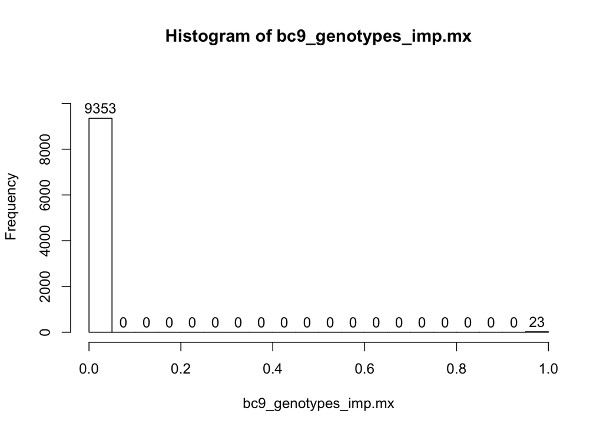

```r
hist(bc9_genotypes_imp.mx, lab=T, ylim=c(0,1.1e4))
```

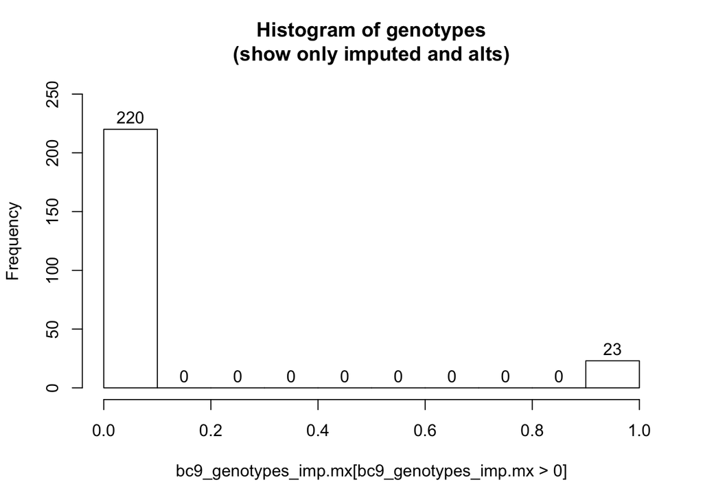

```r
hist(bc9_genotypes_imp.mx[bc9_genotypes_imp.mx>0], lab=T, ylim=c(0,250),
     main="Histogram of genotypes\n(show only imputed and alts)")
```

```r
min(bc9_genotypes_imp.mx[bc9_genotypes_imp.mx>0])
```

```
## [1] 0.001712329
```

```r
# Clean-up
rm(var)
```

# Weight variants by af

Weight by **total** AF using dbeta(AF,1,25)  
Similar to the default weighting in SKAT  
(see parameter weights.beta=c[1,25] for SKAT function)

```r
# Prepare tables for output
bc9_fiv.df <- data.frame(bc9_fiv.df, weight=NA)
bc9_genotypes_imp_wt.mx <- bc9_genotypes_imp.mx

# Apply weighting
for(var in 1:nrow(bc9_genotypes_imp_wt.mx)){

  # Calculate weight
  weight <- dbeta(bc9_fiv.df[var, "total_af"], 1, 25)

  # Write weight to variants table
  weight -> bc9_fiv.df[var,"weight"]

  # Apply weights to genotypes table
  weight * bc9_genotypes_imp.mx[var,] -> bc9_genotypes_imp_wt.mx[var,]

  # Clean-up
  rm(weight)

}

# Explore weights
sum(is.na(bc9_fiv.df$weight))
```

```
## [1] 0
```

```r
mean(bc9_fiv.df$weight)
```

```
## [1] 24.25746
```

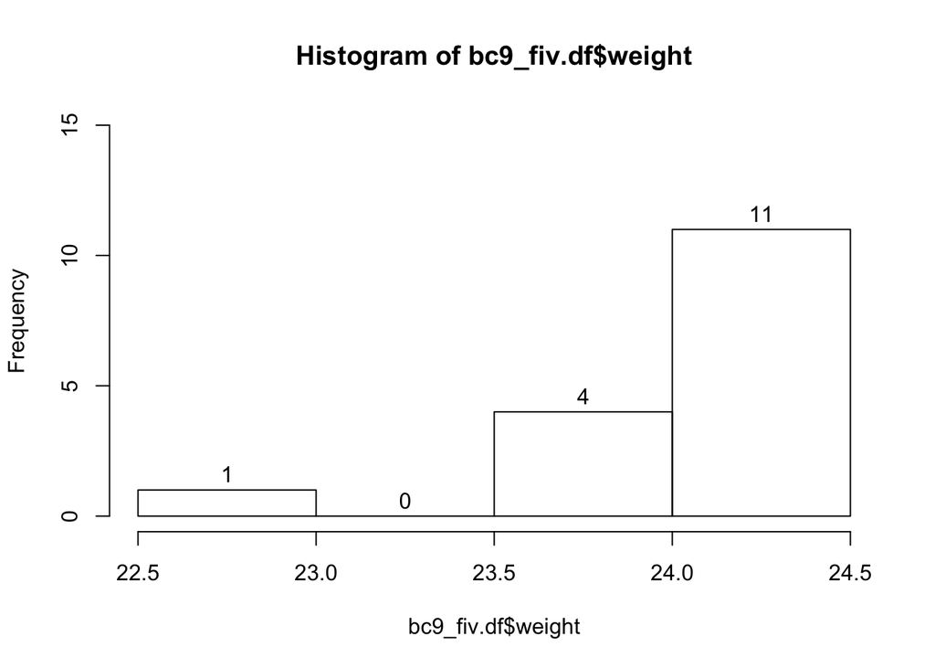

```r
hist(bc9_fiv.df$weight, lab=T, ylim=c(0,15))
```

```r
# Explore weighted genotypes
min(bc9_genotypes_imp_wt.mx)
```

```
## [1] 0
```

```r
min(bc9_genotypes_imp_wt.mx[bc9_genotypes_imp_wt.mx>0])
```

```
## [1] 0.0419372
```

```r
max(bc9_genotypes_imp_wt.mx)
```

```
## [1] 24.49133
```

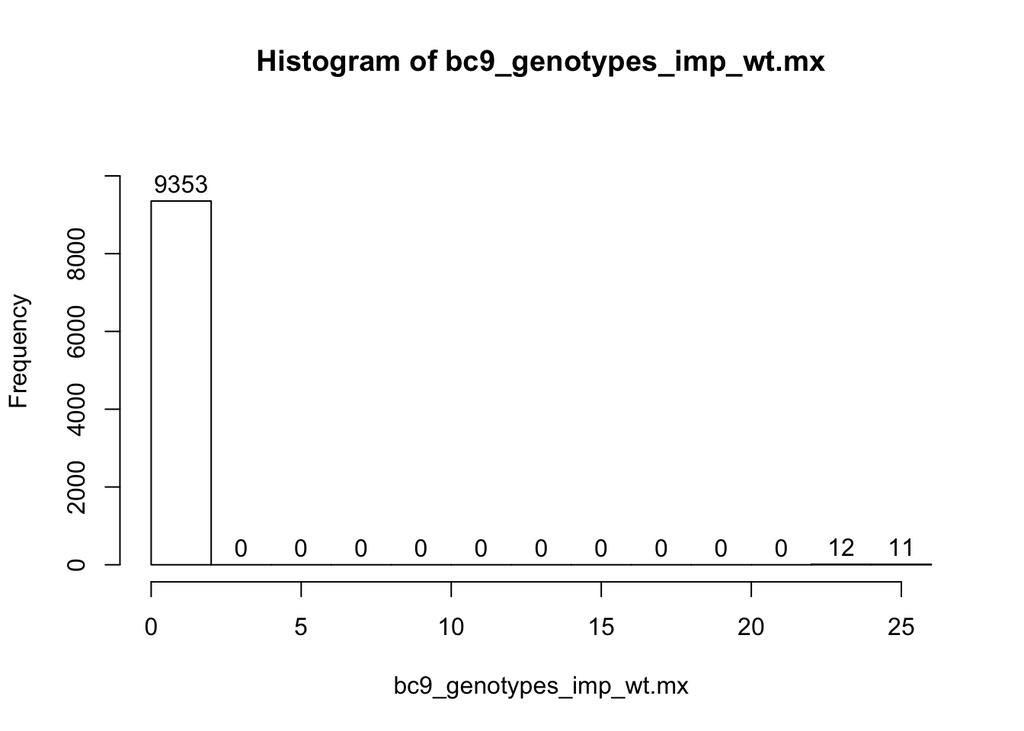

```r
hist(bc9_genotypes_imp_wt.mx, lab=T, ylim=c(0,1.1e4))
```

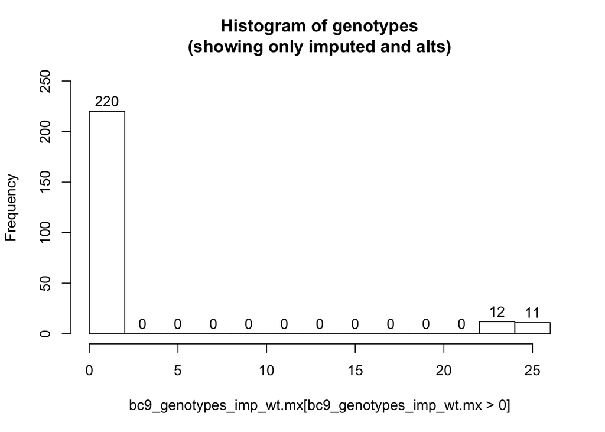

```r
hist(bc9_genotypes_imp_wt.mx[bc9_genotypes_imp_wt.mx>0], lab=T, ylim=c(0,250), main="Histogram of genotypes\n(showing only imputed and alts)")
```

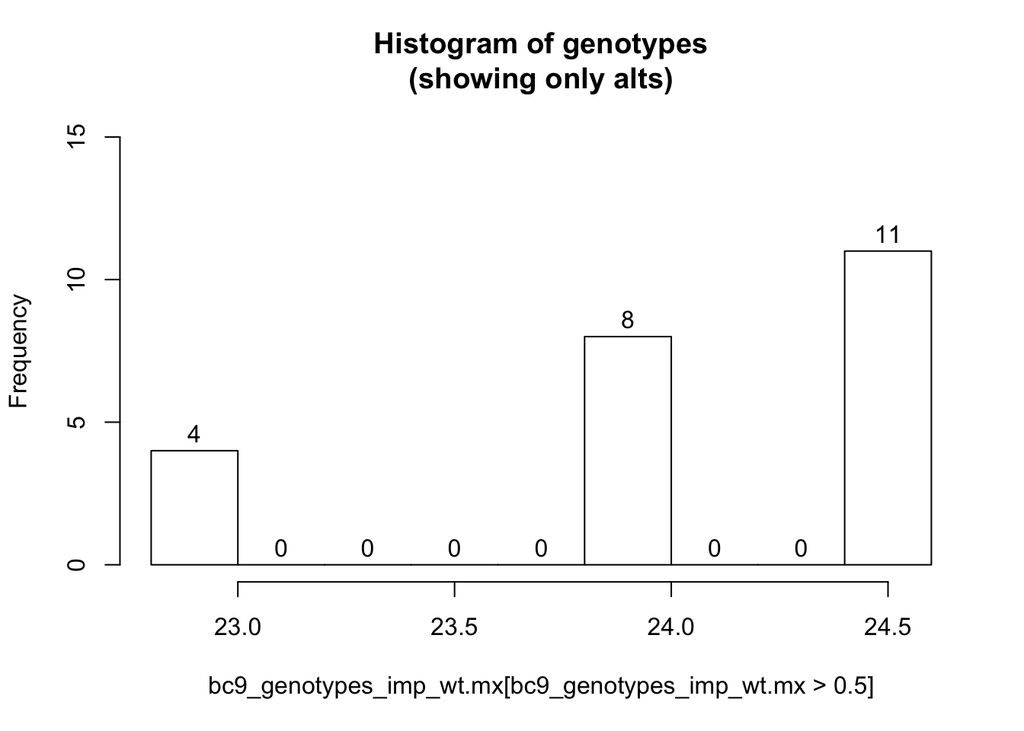

```r
hist(bc9_genotypes_imp_wt.mx[bc9_genotypes_imp_wt.mx>0.5], lab=T, ylim=c(0,15), main="Histogram of genotypes\n(showing only alts)")
```

```r
# clean-up
rm(var)
```

# Aggregate imputed weighted genotypes

```r
bc9_genotypes_imp_wt_aggregated <- apply(bc9_genotypes_imp_wt.mx,2,sum)

bc9_genotypes_imp_wt_aggregated[1:5]
```

```
## 1_S441_L008 2_S134_L007 3_S360_L008  4_S66_L007 5_S395_L008
##   0.0000000   0.0000000   0.1321008   0.0000000   0.2545755
```

# Check data

```r
ls()
```

```
##  [1] "base_folder"                     "bc11_genes"                      "bc9_fiv.df"                      "bc9_genotypes_imp_wt_aggregated" "bc9_genotypes_imp_wt.mx"         "bc9_genotypes_imp.mx"            "bc9_genotypes.mx"                "bc9_variants.df"                 "data_folder"       …
```

```r
dim(genotypes.mx)
```

```
## [1] 1922  586
```

```r
dim(variants.df)
```

```
## [1] 1922   82
```

```r
dim(phenotypes.df)
```

```
## [1] 586  41
```

```r
table(phenotypes.df$cc, useNA = "always")
```

```
##
##   -1    0    1 <NA>
##  197  194  195    0
```

```r
dim(bc9_genotypes.mx)
```

```
## [1]  16 586
```

```r
dim(bc9_genotypes_imp.mx)
```

```
## [1]  16 586
```

```r
dim(bc9_genotypes_imp_wt.mx)
```

```
## [1]  16 586
```

```r
length(bc9_genotypes_imp_wt_aggregated)
```

```
## [1] 586
```

```r
length(bc11_genes)
```

```
## [1] 11
```

```r
dim(bc9_fiv.df)
```

```
## [1] 16 23
```

```r
dim(bc9_variants.df)
```

```
## [1] 185  82
```

```r
# Check consistency of rownames and colnames
sum(colnames(genotypes.mx) != phenotypes.df$sample.ID)
```

```
## [1] 0
```

```r
sum(rownames(genotypes.mx) != variants.df$ID)
```

```
## [1] 0
```

```r
sum(names(bc9_genotypes_imp_wt_aggregated) != phenotypes.df$sample.ID)
```

```
## [1] 0
```

# Save data

```r
save.image(file.path(data_folder, "s01_impute_weight_aggregate_bc9.RData"))
```

# Final section

```r
ls()
```

```
##  [1] "base_folder"                     "bc11_genes"                      "bc9_fiv.df"                      "bc9_genotypes_imp_wt_aggregated" "bc9_genotypes_imp_wt.mx"         "bc9_genotypes_imp.mx"            "bc9_genotypes.mx"                "bc9_variants.df"                 "data_folder"       …
```

```r
Sys.time()
```

```
## [1] "2021-12-30 15:27:34 GMT"
```

```r
gc()
```

```
##           used (Mb) gc trigger (Mb) limit (Mb) max used (Mb)
## Ncells  670973 35.9    1311002 70.1         NA   891434 47.7
## Vcells 2619290 20.0    8388608 64.0      16384  3041839 23.3
```